# Ford GoBike Data Analysis

## Preliminary Wrangling

> Ford GoBike is a regional public bicycle sharing system in the San Francisco Bay Area, California. Beginning operation in August 29th 2013 as Bay Area Bike Share, the Ford GoBike system currently has over 2,600 bicycles in 262 stations across San Francisco, East Bay and San Jose. This data set includes information about individual rides made in a bike-sharing system covering the San Francisco Bay area.

## Gather

```python
# Import all packages and set plots to be embedded inline

import numpy as np
import pandas as pd
import matplotlib.pyplot as plt
import matplotlib.style as style
import matplotlib.ticker as tick
import seaborn as sns
import missingno as mn
from requests import get
from io import BytesIO
from zipfile import ZipFile
import os
import datetime
import math
import calendar
import glob

%matplotlib inline
```

```python
# Function for gathering data from URL and saving into the 'data' subdirectory directory

data = 'data'

def gather_data(year, first_month, final_month, ind):

    for month in range(first_month, final_month + 1):
        month_str = str(month)
        year_str = str(year)
        month_dig = month_str.zfill(2)
        url = 'https://s3.amazonaws.com/baywheels-data/' + year_str + month_dig + ind + '-tripdata.csv.zip'
        response = get(url)
        print(year, " - ", month)

        # Open the zip file, and save extracted data

        unzipped = ZipFile(BytesIO(response.content))
        unzipped.extractall(data)
```

I have manually downloaded the zip file for 2017 data; however, I will use the gather_data function to obtain the 2018, 2019, and 2020 data.

```python
# Gather data for 2018, 2019, and 2020

gather_data(2018, 1, 12, "-fordgobike")
gather_data(2019, 1, 4, "-fordgobike")
gather_data(2019, 5, 12, "-baywheels")
gather_data(2020, 1, 3, "-baywheels")
```

```
2018  -  1
2018  -  2
2018  -  3
2018  -  4
2018  -  5
2018  -  6
2018  -  7
2018  -  8
2018  -  9
2018  -  10
2018  -  11
2018  -  12
2019  -  1
2019  -  2
2019  -  3
```

[output cut: 16 more lines]

I noticed that the data schema changed from May 2020 onwards, and as such, I made the decision to delete the files from May 2020 to July 2020 and limit my study to the data from 2017 to April 2020, for ease of comparison.

```python
# Combine all CSVs into one CSV

os.chdir("/Users/jozofrankovic/Udacity/Project 5/Project Template/data")
extension = 'csv'
files = [i for i in glob.glob('*.{}'.format(extension))]
pd.concat([pd.read_csv(f) for f in files]).to_csv('data.csv', index=False, encoding='utf-8-sig')
```

```python
# Check DataFrame – visual inspection, shape, and info

os.chdir("/Users/jozofrankovic/Udacity/Project 5/Project Template/data")
df = pd.read_csv('data.csv', low_memory=False)
df.head()
```

|  | duration_sec | start_time | end_time | start_station_id | start_station_name | start_station_latitude | start_station_longitude | end_station_id | end_station_name | end_station_latitude | end_station_longitude | bike_id | user_type | bike_share_for_all_trip | rental_access_method |
| --- | --- | --- | --- | --- | --- | --- | --- | --- | --- | --- | --- | --- | --- | --- | --- |
| 0 | 598 | 2018-02-28 23:59:47.0970 | 2018-03-01 00:09:45.1870 | 284.0 | Yerba Buena Center for the Arts (Howard St at ... | 37.784872 | -122.400876 | 114.0 | Rhode Island St at 17th St | 37.764478 | -122.402570 | 1035 | Subscriber | No | NaN |
| 1 | 943 | 2018-02-28 23:21:16.4950 | 2018-02-28 23:36:59.9740 | 6.0 | The Embarcadero at Sansome St | 37.804770 | -122.403234 | 324.0 | Union Square (Powell St at Post St) | 37.788300 | -122.408531 | 1673 | Customer | No | NaN |
| 2 | 18587 | 2018-02-28 18:20:55.1900 | 2018-02-28 23:30:42.9250 | 93.0 | 4th St at Mission Bay Blvd S | 37.770407 | -122.391198 | 15.0 | San Francisco Ferry Building (Harry Bridges Pl... | 37.795392 | -122.394203 | 3498 | Customer | No | NaN |
| 3 | 18558 | 2018-02-28 18:20:53.6210 | 2018-02-28 23:30:12.4500 | 93.0 | 4th St at Mission Bay Blvd S | 37.770407 | -122.391198 | 15.0 | San Francisco Ferry Building (Harry Bridges Pl... | 37.795392 | -122.394203 | 3129 | Customer | No | NaN |
| 4 | 885 | 2018-02-28 23:15:12.8580 | 2018-02-28 23:29:58.6080 | 308.0 | San Pedro Square | 37.336802 | -121.894090 | 297.0 | Locust St at Grant St | 37.322980 | -121.887931 | 1839 | Subscriber | Yes | NaN |

```python
df.shape
```

```
(5795411, 15)
```

```python
df.info()
```

```
<class 'pandas.core.frame.DataFrame'>
RangeIndex: 5795411 entries, 0 to 5795410
Data columns (total 15 columns):
 #   Column                   Dtype
---  ------                   -----
 0   duration_sec             int64
 1   start_time               object
 2   end_time                 object
 3   start_station_id         float64
 4   start_station_name       object
 5   start_station_latitude   float64
 6   start_station_longitude  float64
 7   end_station_id           float64
 8   end_station_name         object
 9   end_station_latitude     float64
 10  end_station_longitude    float64
 11  bike_id                  int64
 12  user_type                object
 13  bike_share_for_all_trip  object
 14  rental_access_method     object
dtypes: float64(6), int64(2), object(7)
memory usage: 663.2+ MB
```

```python
df.sample(20)
```

|  | duration_sec | start_time | end_time | start_station_id | start_station_name | start_station_latitude | start_station_longitude | end_station_id | end_station_name | end_station_latitude | end_station_longitude | bike_id | user_type | bike_share_for_all_trip | rental_access_method |
| --- | --- | --- | --- | --- | --- | --- | --- | --- | --- | --- | --- | --- | --- | --- | --- |
| 752594 | 1065 | 2018-09-21 21:55:38.5360 | 2018-09-21 22:13:24.3060 | 23.0 | The Embarcadero at Steuart St | 37.791464 | -122.391034 | 58.0 | Market St at 10th St | 37.776619 | -122.417385 | 3981 | Subscriber | No | NaN |
| 1105167 | 1313 | 2017-10-21 08:34:24.3430 | 2017-10-21 08:56:17.7510 | 47.0 | 4th St at Harrison St | 37.780955 | -122.399749 | 6.0 | The Embarcadero at Sansome St | 37.804770 | -122.403234 | 2418 | Subscriber | NaN | NaN |
| 3248379 | 355 | 2019-01-10 10:29:42.3340 | 2019-01-10 10:35:38.2240 | 70.0 | Central Ave at Fell St | 37.773311 | -122.444293 | 95.0 | Sanchez St at 15th St | 37.766219 | -122.431060 | 5255 | Subscriber | Yes | NaN |
| 3840703 | 152 | 2018-08-23 18:16:55.2900 | 2018-08-23 18:19:28.0760 | 160.0 | West Oakland BART Station | 37.805318 | -122.294837 | 230.0 | 14th St at Mandela Pkwy | 37.810743 | -122.291415 | 1364 | Subscriber | No | NaN |
| 1433596 | 633 | 2018-06-26 18:05:13.2650 | 2018-06-26 18:15:47.2240 | 280.0 | San Fernando at 7th St | 37.337246 | -121.883074 | 305.0 | Ryland Park | 37.342725 | -121.895617 | 62 | Subscriber | Yes | NaN |
| 3967234 | 468 | 2018-08-03 09:14:26.3830 | 2018-08-03 09:22:14.7590 | 20.0 | Mechanics Monument Plaza (Market St at Bush St) | 37.791300 | -122.399051 | 9.0 | Broadway at Battery St | 37.798572 | -122.400869 | 1446 | Subscriber | No | NaN |
| 3951765 | 312 | 2018-08-06 12:23:07.4740 | 2018-08-06 12:28:20.0050 | 22.0 | Howard St at Beale St | 37.789756 | -122.394643 | 21.0 | Montgomery St BART Station (Market St at 2nd St) | 37.789625 | -122.400811 | 3551 | Subscriber | No | NaN |
| 1459328 | 410 | 2018-06-22 17:10:19.2830 | 2018-06-22 17:17:09.6110 | 171.0 | Rockridge BART Station | 37.844279 | -122.251900 | 188.0 | Dover St at 57th St | 37.842630 | -122.267738 | 3360 | Subscriber | No | NaN |
| 1417671 | 242 | 2018-06-28 18:06:10.8720 | 2018-06-28 18:10:12.9430 | 176.0 | MacArthur BART Station | 37.828410 | -122.266315 | 211.0 | Broadway at 40th St | 37.827757 | -122.256716 | 3508 | Subscriber | No | NaN |
| 5331266 | 640 | 2019-11-21 17:36:35.6730 | 2019-11-21 17:47:15.7620 | 3.0 | Powell St BART Station (Market St at 4th St) | 37.786375 | -122.404904 | 89.0 | Division St at Potrero Ave | 37.769218 | -122.407646 | 13001 | Subscriber | No | NaN |
| 3010707 | 623 | 2019-05-16 08:53:58.3120 | 2019-05-16 09:04:22.2090 | 70.0 | Central Ave at Fell St | 37.773311 | -122.444293 | 58.0 | Market St at 10th St | 37.776619 | -122.417385 | 1434 | Customer | No | NaN |
| 67033 | 434 | 2018-02-10 10:06:09.6900 | 2018-02-10 10:13:24.3270 | 167.0 | College Ave at Harwood Ave | 37.848152 | -122.252160 | 188.0 | Dover St at 57th St | 37.842630 | -122.267738 | 3301 | Subscriber | No | NaN |
| 1932445 | 1195 | 2019-03-22 18:37:16.7740 | 2019-03-22 18:57:12.7530 | 26.0 | 1st St at Folsom St | 37.787290 | -122.394380 | 74.0 | Laguna St at Hayes St | 37.776435 | -122.426244 | 6083 | Subscriber | No | NaN |
| 3176225 | 1353 | 2019-01-23 10:02:45.8040 | 2019-01-23 10:25:19.5390 | 239.0 | Bancroft Way at Telegraph Ave | 37.868813 | -122.258764 | 337.0 | Webster St at 19th St | 37.806970 | -122.266588 | 5212 | Subscriber | No | NaN |
| 2225189 | 476 | 2019-06-12 21:05:38.5470 | 2019-06-12 21:13:34.8550 | 92.0 | Mission Bay Kids Park | 37.772301 | -122.393028 | 47.0 | 4th St at Harrison St | 37.780955 | -122.399749 | 3243 | Subscriber | No | NaN |
| 64276 | 712 | 2018-02-11 10:08:20.8270 | 2018-02-11 10:20:13.7790 | 114.0 | Rhode Island St at 17th St | 37.764478 | -122.402570 | 36.0 | Folsom St at 3rd St | 37.783830 | -122.398870 | 327 | Subscriber | No | NaN |
| 5186409 | 1056 | 2019-12-16 19:47:00.9880 | 2019-12-16 20:04:37.4340 | 28.0 | The Embarcadero at Bryant St | 37.787168 | -122.388098 | 129.0 | Harrison St at 20th St | 37.758862 | -122.412544 | 12261 | Customer | NaN | NaN |
| 3908673 | 1041 | 2018-08-13 08:17:23.7450 | 2018-08-13 08:34:45.3780 | 29.0 | O'Farrell St at Divisadero St | 37.782405 | -122.439446 | 21.0 | Montgomery St BART Station (Market St at 2nd St) | 37.789625 | -122.400811 | 3225 | Subscriber | No | NaN |
| 3110161 | 899 | 2019-01-31 10:47:48.1530 | 2019-01-31 11:02:48.1480 | 178.0 | Broadway at 30th St | 37.819381 | -122.261928 | 187.0 | Jack London Square | 37.796248 | -122.279352 | 3516 | Subscriber | No | NaN |
| 4529270 | 663 | 2020-02-04 11:09:27.3460 | 2020-02-04 11:20:30.7950 | 43.0 | San Francisco Public Library (Grove St at Hyde... | 37.778768 | -122.415929 | 468.0 | Grove St at Gough St | 37.777870 | -122.422953 | 2006 | Customer | NaN | NaN |

```python
# Check for null values

df.isnull().sum()
```

```
duration_sec                     0
start_time                       0
end_time                         0
start_station_id            578807
start_station_name          576973
start_station_latitude           0
start_station_longitude          0
end_station_id              580455
end_station_name            578629
end_station_latitude             0
end_station_longitude            0
bike_id                          0
user_type                        0
bike_share_for_all_trip    1667966
rental_access_method       5056715
dtype: int64
```

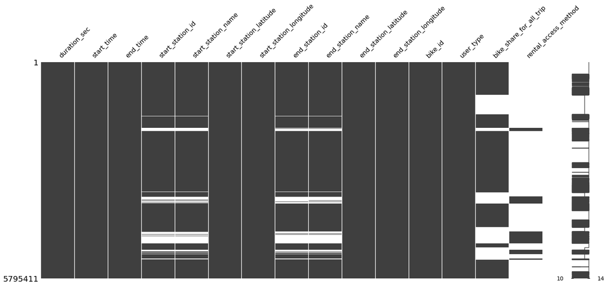

```python
# Visualise the missing values

mn.matrix(df);
```

There are some null values across the station information (start_station_id, start_station_name, end_station_id, end_station_name). I do not expect to centre my analysis on these attributes, so I could drop the nulls anyway.

There are significantly more null values for bike_share_for_all_trip and even moreso for rental_access_method. I will not need these attributes either.

```python
df.describe()
```

|  | duration_sec | start_station_id | start_station_latitude | start_station_longitude | end_station_id | end_station_latitude | end_station_longitude | bike_id |
| --- | --- | --- | --- | --- | --- | --- | --- | --- |
| count | 5.795411e+06 | 5.216604e+06 | 5.795411e+06 | 5.795411e+06 | 5.214956e+06 | 5.795411e+06 | 5.795411e+06 | 5.795411e+06 |
| mean | 8.496090e+02 | 1.341785e+02 | 3.776353e+01 | -1.223520e+02 | 1.310317e+02 | 3.776315e+01 | -1.223497e+02 | 6.687199e+04 |
| std | 2.233872e+03 | 1.158862e+02 | 1.434050e-01 | 3.410302e-01 | 1.150914e+02 | 2.011897e-01 | 5.704336e-01 | 1.863825e+05 |
| min | 6.000000e+01 | 3.000000e+00 | 0.000000e+00 | -1.225143e+02 | 3.000000e+00 | 0.000000e+00 | -1.225758e+02 | 4.000000e+00 |
| 25% | 3.600000e+02 | 3.900000e+01 | 3.776971e+01 | -1.224136e+02 | 3.300000e+01 | 3.777003e+01 | -1.224117e+02 | 1.640000e+03 |
| 50% | 5.720000e+02 | 9.500000e+01 | 3.778053e+01 | -1.223989e+02 | 9.200000e+01 | 3.778079e+01 | -1.223984e+02 | 3.159000e+03 |
| 75% | 8.930000e+02 | 2.090000e+02 | 3.779539e+01 | -1.223881e+02 | 2.000000e+02 | 3.779539e+01 | -1.223881e+02 | 9.600000e+03 |
| max | 9.121100e+05 | 5.210000e+02 | 4.551000e+01 | 0.000000e+00 | 5.210000e+02 | 4.551000e+01 | 0.000000e+00 | 9.999600e+05 |

## Assess

**Quality issues**

- start_time and end_time are objects rather than timestamps
- bike_id, start_station_id, and end_station_id should be set to object
- user_id should be set to category
- bike_share_for_all_trip and rental_access_method can be dropped
- Dataset can be enhanced by created columns for day, month, weekday, hour, year, etc., as well as duration in minutes
- There are some nulls across the station information as aforementioned

## Clean

```python
# Create a copy for cleaning

df_clean = df.copy()
```

**Define**

Set appropriate data types

**Code**

```python
# Set dates to timestamp

df_clean.start_time = pd.to_datetime(df_clean.start_time)
df_clean.end_time = pd.to_datetime(df_clean.end_time)
```

```python
# Set bike_id, start_station_id, and end_station_id to object

df_clean.bike_id = df_clean.bike_id.astype(str)
df_clean.start_station_id = df_clean.start_station_id.astype(str)
df_clean.end_station_id = df_clean.end_station_id.astype(str)
```

```python
# Set user_id to category

df_clean.user_type = df_clean.user_type.astype('category')
```

**Test**

```python
df_clean.info()
```

```
<class 'pandas.core.frame.DataFrame'>
RangeIndex: 5795411 entries, 0 to 5795410
Data columns (total 15 columns):
 #   Column                   Dtype
---  ------                   -----
 0   duration_sec             int64
 1   start_time               datetime64[ns]
 2   end_time                 datetime64[ns]
 3   start_station_id         object
 4   start_station_name       object
 5   start_station_latitude   float64
 6   start_station_longitude  float64
 7   end_station_id           object
 8   end_station_name         object
 9   end_station_latitude     float64
 10  end_station_longitude    float64
 11  bike_id                  object
 12  user_type                category
 13  bike_share_for_all_trip  object
 14  rental_access_method     object
dtypes: category(1), datetime64[ns](2), float64(4), int64(1), object(7)
memory usage: 624.5+ MB
```

**Define**

Enhance dataset with new date-related and distance attributes

**Code**

```python
# Extract start time month name

df_clean['start_time_month_name'] = df_clean['start_time'].dt.strftime('%B')
```

```python
# Extract start time month number

df_clean['start_time_month'] = df_clean['start_time'].dt.month.astype(int)
```

```python
# Extract start time weekdays

df_clean['start_time_weekday'] = df_clean['start_time'].dt.strftime('%a')
```

```python
# Extract start time day

df_clean['start_time_day'] = df_clean['start_time'].dt.day.astype(int)
```

```python
# Extract start time hour

df_clean['start_time_hour'] = df_clean['start_time'].dt.hour
```

```python
# Extract year and month combination

df_clean['start_time_year_month'] = df_clean['start_time'].dt.strftime('%y' + '-' + '%m')
```

```python
# Extract start time year

df_clean['start_time_year'] = df_clean['start_time'].dt.year.astype('int')
```

```python
# Create duration in minutes

df_clean['duration_minute'] = df_clean['duration_sec']/60
```

**Test**

```python
df_clean.head()
```

|  | duration_sec | start_time | end_time | start_station_id | start_station_name | start_station_latitude | start_station_longitude | end_station_id | end_station_name | end_station_latitude | ... | bike_share_for_all_trip | rental_access_method | start_time_month_name | start_time_month | start_time_weekday | start_time_day | start_time_hour | start_time_year_month | start_time_year | duration_minute |
| --- | --- | --- | --- | --- | --- | --- | --- | --- | --- | --- | --- | --- | --- | --- | --- | --- | --- | --- | --- | --- | --- |
| 0 | 598 | 2018-02-28 23:59:47.097 | 2018-03-01 00:09:45.187 | 284.0 | Yerba Buena Center for the Arts (Howard St at ... | 37.784872 | -122.400876 | 114.0 | Rhode Island St at 17th St | 37.764478 | ... | No | NaN | February | 2 | Wed | 28 | 23 | 18-02 | 2018 | 9.966667 |
| 1 | 943 | 2018-02-28 23:21:16.495 | 2018-02-28 23:36:59.974 | 6.0 | The Embarcadero at Sansome St | 37.804770 | -122.403234 | 324.0 | Union Square (Powell St at Post St) | 37.788300 | ... | No | NaN | February | 2 | Wed | 28 | 23 | 18-02 | 2018 | 15.716667 |
| 2 | 18587 | 2018-02-28 18:20:55.190 | 2018-02-28 23:30:42.925 | 93.0 | 4th St at Mission Bay Blvd S | 37.770407 | -122.391198 | 15.0 | San Francisco Ferry Building (Harry Bridges Pl... | 37.795392 | ... | No | NaN | February | 2 | Wed | 28 | 18 | 18-02 | 2018 | 309.783333 |
| 3 | 18558 | 2018-02-28 18:20:53.621 | 2018-02-28 23:30:12.450 | 93.0 | 4th St at Mission Bay Blvd S | 37.770407 | -122.391198 | 15.0 | San Francisco Ferry Building (Harry Bridges Pl... | 37.795392 | ... | No | NaN | February | 2 | Wed | 28 | 18 | 18-02 | 2018 | 309.300000 |
| 4 | 885 | 2018-02-28 23:15:12.858 | 2018-02-28 23:29:58.608 | 308.0 | San Pedro Square | 37.336802 | -121.894090 | 297.0 | Locust St at Grant St | 37.322980 | ... | Yes | NaN | February | 2 | Wed | 28 | 23 | 18-02 | 2018 | 14.750000 |

5 rows × 23 columns

**Define**

Resolve null values

**Code**

```python
df_clean.shape
```

```
(5795411, 23)
```

```python
df_clean.isnull().sum()
```

```
duration_sec                     0
start_time                       0
end_time                         0
start_station_id                 0
start_station_name          576973
start_station_latitude           0
start_station_longitude          0
end_station_id                   0
end_station_name            578629
end_station_latitude             0
end_station_longitude            0
bike_id                          0
user_type                        0
bike_share_for_all_trip    1667966
rental_access_method       5056715
start_time_month_name            0
start_time_month                 0
start_time_weekday               0
start_time_day                   0
start_time_hour                  0
start_time_year_month            0
start_time_year                  0
duration_minute                  0
dtype: int64
```

```python
# Drop bike_share_for_all_trip, rental_access_method, start_station_name, and end_station_name

df_clean.drop(['bike_share_for_all_trip', 'rental_access_method', 'start_station_name', 'end_station_name'], axis = 1, inplace = True)
```

**Test**

```python
df_clean.isnull().sum()
```

```
duration_sec               0
start_time                 0
end_time                   0
start_station_id           0
start_station_latitude     0
start_station_longitude    0
end_station_id             0
end_station_latitude       0
end_station_longitude      0
bike_id                    0
user_type                  0
start_time_month_name      0
start_time_month           0
start_time_weekday         0
start_time_day             0
start_time_hour            0
start_time_year_month      0
start_time_year            0
duration_minute            0
dtype: int64
```

**Define**

Check for duplicated values

```python
# Check for duplicated values

df_clean.duplicated().sum()
```

```
7512
```

```python
# Check of DataFrame information

df_clean.shape
```

```
(5795411, 19)
```

**Code**

```python
# Drop duplicates

df_clean.drop_duplicates(keep=False, inplace=True)
```

**Test**

```python
# Check for duplicated values

df_clean.duplicated().sum()
```

```
0
```

```python
# Final check of DataFrame information

df_clean.shape
```

```
(5780387, 19)
```

```python
df_clean.info()
```

```
<class 'pandas.core.frame.DataFrame'>
Int64Index: 5780387 entries, 0 to 5795410
Data columns (total 19 columns):
 #   Column                   Dtype
---  ------                   -----
 0   duration_sec             int64
 1   start_time               datetime64[ns]
 2   end_time                 datetime64[ns]
 3   start_station_id         object
 4   start_station_latitude   float64
 5   start_station_longitude  float64
 6   end_station_id           object
 7   end_station_latitude     float64
 8   end_station_longitude    float64
 9   bike_id                  object
 10  user_type                category
 11  start_time_month_name    object
 12  start_time_month         int64
 13  start_time_weekday       object
 14  start_time_day           int64
 15  start_time_hour          int64
 16  start_time_year_month    object
 17  start_time_year          int64
 18  duration_minute          float64
dtypes: category(1), datetime64[ns](2), float64(5), int64(5), object(6)
memory usage: 843.4+ MB
```

**Define**

Check for duration outliers

```python
# Check duration lengths

df_clean.nlargest(10, ['duration_minute'])
```

|  | duration_sec | start_time | end_time | start_station_id | start_station_latitude | start_station_longitude | end_station_id | end_station_latitude | end_station_longitude | bike_id | user_type | start_time_month_name | start_time_month | start_time_weekday | start_time_day | start_time_hour | start_time_year_month | start_time_year | duration_minute |
| --- | --- | --- | --- | --- | --- | --- | --- | --- | --- | --- | --- | --- | --- | --- | --- | --- | --- | --- | --- |
| 5269627 | 912110 | 2019-12-19 23:15:36.000 | 2019-12-30 12:37:26.000 | nan | 37.323757 | -121.878614 | nan | 37.327656 | -121.868598 | 614329 | Customer | December | 12 | Thu | 19 | 23 | 19-12 | 2019 | 15201.833333 |
| 3616496 | 811077 | 2020-01-09 16:23:21.000 | 2020-01-19 01:41:19.000 | nan | 37.336035 | -121.899836 | nan | 37.336549 | -121.900961 | 231296 | Subscriber | January | 1 | Thu | 9 | 16 | 20-01 | 2020 | 13517.950000 |
| 1023029 | 86369 | 2017-11-12 10:44:32.043 | 2017-11-13 10:44:01.820 | 308.0 | 37.336802 | -121.894090 | 308.0 | 37.336802 | -121.894090 | 2231 | Customer | November | 11 | Sun | 12 | 10 | 17-11 | 2017 | 1439.483333 |
| 92914 | 86366 | 2018-02-03 17:32:04.042 | 2018-02-04 17:31:30.788 | 197.0 | 37.808848 | -122.249680 | 197.0 | 37.808848 | -122.249680 | 1486 | Customer | February | 2 | Sat | 3 | 17 | 18-02 | 2018 | 1439.433333 |
| 1107675 | 86355 | 2017-10-19 11:24:01.807 | 2017-10-20 11:23:17.737 | 123.0 | 37.760594 | -122.414817 | 70.0 | 37.773311 | -122.444293 | 229 | Customer | October | 10 | Thu | 19 | 11 | 17-10 | 2017 | 1439.250000 |
| 939055 | 86325 | 2017-12-09 10:46:05.919 | 2017-12-10 10:44:51.113 | 212.0 | 37.824931 | -122.260479 | 212.0 | 37.824931 | -122.260479 | 3482 | Customer | December | 12 | Sat | 9 | 10 | 17-12 | 2017 | 1438.750000 |
| 4476315 | 86317 | 2020-02-17 11:42:26.059 | 2020-02-18 11:41:03.741 | 295.0 | 37.332794 | -121.875926 | 294.0 | 37.327581 | -121.884559 | 10643 | Customer | February | 2 | Mon | 17 | 11 | 20-02 | 2020 | 1438.616667 |
| 792442 | 86281 | 2018-09-15 13:10:50.749 | 2018-09-16 13:08:52.668 | 147.0 | 37.744067 | -122.421472 | 134.0 | 37.752428 | -122.420628 | 2175 | Subscriber | September | 9 | Sat | 15 | 13 | 18-09 | 2018 | 1438.016667 |
| 939056 | 86281 | 2017-12-09 10:46:42.231 | 2017-12-10 10:44:44.161 | 212.0 | 37.824931 | -122.260479 | 212.0 | 37.824931 | -122.260479 | 3418 | Customer | December | 12 | Sat | 9 | 10 | 17-12 | 2017 | 1438.016667 |
| 1004590 | 86252 | 2017-11-18 12:16:33.230 | 2017-11-19 12:14:05.244 | 245.0 | 37.870348 | -122.267764 | 18.0 | 37.850222 | -122.260172 | 1214 | Customer | November | 11 | Sat | 18 | 12 | 17-11 | 2017 | 1437.533333 |

**Code**

```python
# Remove two clear outliers

df_clean.drop([5269627, 3616496], axis=0, inplace=True)
```

**Test**

```python
# Check and test

df_clean.nlargest(10, ['duration_minute'])
```

|  | duration_sec | start_time | end_time | start_station_id | start_station_latitude | start_station_longitude | end_station_id | end_station_latitude | end_station_longitude | bike_id | user_type | start_time_month_name | start_time_month | start_time_weekday | start_time_day | start_time_hour | start_time_year_month | start_time_year | duration_minute |
| --- | --- | --- | --- | --- | --- | --- | --- | --- | --- | --- | --- | --- | --- | --- | --- | --- | --- | --- | --- |
| 1023029 | 86369 | 2017-11-12 10:44:32.043 | 2017-11-13 10:44:01.820 | 308.0 | 37.336802 | -121.894090 | 308.0 | 37.336802 | -121.894090 | 2231 | Customer | November | 11 | Sun | 12 | 10 | 17-11 | 2017 | 1439.483333 |
| 92914 | 86366 | 2018-02-03 17:32:04.042 | 2018-02-04 17:31:30.788 | 197.0 | 37.808848 | -122.249680 | 197.0 | 37.808848 | -122.249680 | 1486 | Customer | February | 2 | Sat | 3 | 17 | 18-02 | 2018 | 1439.433333 |
| 1107675 | 86355 | 2017-10-19 11:24:01.807 | 2017-10-20 11:23:17.737 | 123.0 | 37.760594 | -122.414817 | 70.0 | 37.773311 | -122.444293 | 229 | Customer | October | 10 | Thu | 19 | 11 | 17-10 | 2017 | 1439.250000 |
| 939055 | 86325 | 2017-12-09 10:46:05.919 | 2017-12-10 10:44:51.113 | 212.0 | 37.824931 | -122.260479 | 212.0 | 37.824931 | -122.260479 | 3482 | Customer | December | 12 | Sat | 9 | 10 | 17-12 | 2017 | 1438.750000 |
| 4476315 | 86317 | 2020-02-17 11:42:26.059 | 2020-02-18 11:41:03.741 | 295.0 | 37.332794 | -121.875926 | 294.0 | 37.327581 | -121.884559 | 10643 | Customer | February | 2 | Mon | 17 | 11 | 20-02 | 2020 | 1438.616667 |
| 792442 | 86281 | 2018-09-15 13:10:50.749 | 2018-09-16 13:08:52.668 | 147.0 | 37.744067 | -122.421472 | 134.0 | 37.752428 | -122.420628 | 2175 | Subscriber | September | 9 | Sat | 15 | 13 | 18-09 | 2018 | 1438.016667 |
| 939056 | 86281 | 2017-12-09 10:46:42.231 | 2017-12-10 10:44:44.161 | 212.0 | 37.824931 | -122.260479 | 212.0 | 37.824931 | -122.260479 | 3418 | Customer | December | 12 | Sat | 9 | 10 | 17-12 | 2017 | 1438.016667 |
| 1004590 | 86252 | 2017-11-18 12:16:33.230 | 2017-11-19 12:14:05.244 | 245.0 | 37.870348 | -122.267764 | 18.0 | 37.850222 | -122.260172 | 1214 | Customer | November | 11 | Sat | 18 | 12 | 17-11 | 2017 | 1437.533333 |
| 4515827 | 86239 | 2020-02-06 17:03:46.438 | 2020-02-07 17:01:05.703 | 486.0 | 37.778487 | -122.458645 | 440.0 | 37.765910 | -122.449257 | 3643 | Customer | February | 2 | Thu | 6 | 17 | 20-02 | 2020 | 1437.316667 |
| 5173888 | 86230 | 2019-12-18 08:35:17.307 | 2019-12-19 08:32:27.444 | 176.0 | 37.828410 | -122.266315 | 211.0 | 37.827757 | -122.256716 | 11724 | Customer | December | 12 | Wed | 18 | 8 | 19-12 | 2019 | 1437.166667 |

```python
# Export DataFrame to CSV

df_clean.to_csv('data_clean.csv', index=False, encoding='utf-8-sig')
```

### What is the structure of your dataset?

> There are 5,780,385 records in the dataset, with features including duration_sec, start_time, end_time, bike_id, user_type, station information, and other date information.

> This covers three broad categories of data: trip duration, station information, and bike/customer information. I have enhanced this data further by broadening out the datetime and duration information for analysis, including creating new attributes through feature engineering.

### What is/are the main feature(s) of interest in your dataset?

> I am most interested in the date time data to spot trends in terms of peak periods of bike usage throughout the day, week, month, year.

### What features in the dataset do you think will help support your investigation into your feature(s) of interest?

> I expect I will use the date time information I have extrapolated as well as the duration and user type information.

## Univariate Exploration

```python
# Import clean dataset

df_clean = pd.read_csv('data_clean.csv', low_memory=False)
df_clean.head()
```

|  | duration_sec | start_time | end_time | start_station_id | start_station_latitude | start_station_longitude | end_station_id | end_station_latitude | end_station_longitude | bike_id | user_type | start_time_month_name | start_time_month | start_time_weekday | start_time_day | start_time_hour | start_time_year_month | start_time_year | duration_minute |
| --- | --- | --- | --- | --- | --- | --- | --- | --- | --- | --- | --- | --- | --- | --- | --- | --- | --- | --- | --- |
| 0 | 598 | 2018-02-28 23:59:47.097 | 2018-03-01 00:09:45.187 | 284.0 | 37.784872 | -122.400876 | 114.0 | 37.764478 | -122.402570 | 1035 | Subscriber | February | 2 | Wed | 28 | 23 | 18-02 | 2018 | 9.966667 |
| 1 | 943 | 2018-02-28 23:21:16.495 | 2018-02-28 23:36:59.974 | 6.0 | 37.804770 | -122.403234 | 324.0 | 37.788300 | -122.408531 | 1673 | Customer | February | 2 | Wed | 28 | 23 | 18-02 | 2018 | 15.716667 |
| 2 | 18587 | 2018-02-28 18:20:55.190 | 2018-02-28 23:30:42.925 | 93.0 | 37.770407 | -122.391198 | 15.0 | 37.795392 | -122.394203 | 3498 | Customer | February | 2 | Wed | 28 | 18 | 18-02 | 2018 | 309.783333 |
| 3 | 18558 | 2018-02-28 18:20:53.621 | 2018-02-28 23:30:12.450 | 93.0 | 37.770407 | -122.391198 | 15.0 | 37.795392 | -122.394203 | 3129 | Customer | February | 2 | Wed | 28 | 18 | 18-02 | 2018 | 309.300000 |
| 4 | 885 | 2018-02-28 23:15:12.858 | 2018-02-28 23:29:58.608 | 308.0 | 37.336802 | -121.894090 | 297.0 | 37.322980 | -121.887931 | 1839 | Subscriber | February | 2 | Wed | 28 | 23 | 18-02 | 2018 | 14.750000 |

```python
# Use clean dataset

df_clean.shape
```

```
(5780385, 19)
```

```python
# Set sns styles

sns.set_style('whitegrid')
sns.set_context("talk")
sns.set(font_scale=1.25)
```

```python
# Function for ticks to be more easily read

def transform_axis_format(tick_val, pos):
    if tick_val >= 1000:
        val = int(tick_val/1000)
        return '{:d}K'.format(val)
    elif tick_val >= 1000000:
        val = int(tick_val/1000000)
        return '{:d}M'.format(val)
    else:
        return int(tick_val)
```

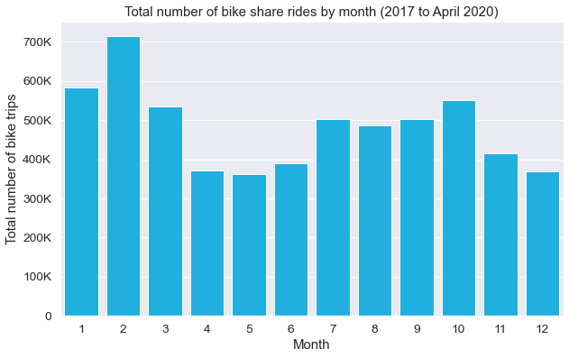

```python
# Monthly bike share rides

plt.figure(figsize = [10, 6])
ax = sns.countplot(data=df_clean, x='start_time_month', color='deepskyblue')
ax.set(xlabel='Month', ylabel='Total number of bike trips')
plt.title('Total number of bike share rides by month (2017 to April 2020)')
ax.yaxis.set_major_formatter(tick.FuncFormatter(transform_axis_format))
plt.show();
```

This visualisation shows that the peak months for bike share rides are January, February, March, and October.

The lowest demand comes in April, May, June, and December.

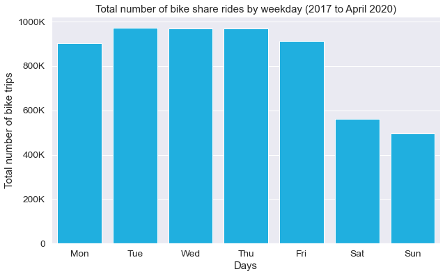

```python
# Weekday bike share rides

plt.figure(figsize = [10, 6])
plt.ticklabel_format(style='plain', axis='y')
weekday = ['Mon', 'Tue', 'Wed', 'Thu', 'Fri', 'Sat', 'Sun']
ax = sns.countplot(data=df_clean, x='start_time_weekday', color = 'deepskyblue', order=weekday)
ax.set(xlabel='Days', ylabel='Total number of bike trips')
plt.title('Total number of bike share rides by weekday (2017 to April 2020)')
ax.yaxis.set_major_formatter(tick.FuncFormatter(transform_axis_format))
plt.show();
```

This visualisation shows there is some kind of weekend effect present, as the demand for bike share rides on Saturday and Sunday is significantly lower in comparison to Monday to Friday.

My hypothesis is that the ride shares are used significantly for commute to work / school.

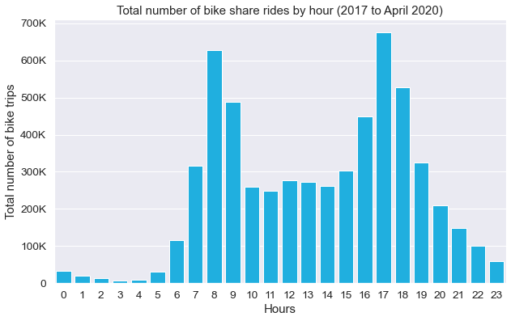

```python
# Hourly bike share rides

plt.figure(figsize = [10, 6])
ax = sns.countplot(data=df_clean, x='start_time_hour', color = 'deepskyblue')
ax.set(xlabel='Hours', ylabel='Total number of bike trips')
plt.title('Total number of bike share rides by hour (2017 to April 2020)')
ax.yaxis.set_major_formatter(tick.FuncFormatter(transform_axis_format))
plt.show();
```

Interestingly, the peak hours of bike share rides are from 8:00 am – 9:00 am and 5:00 pm – 6:00 pm. This further adds to my hypothesis that rides are used predominantly for commute purposes.

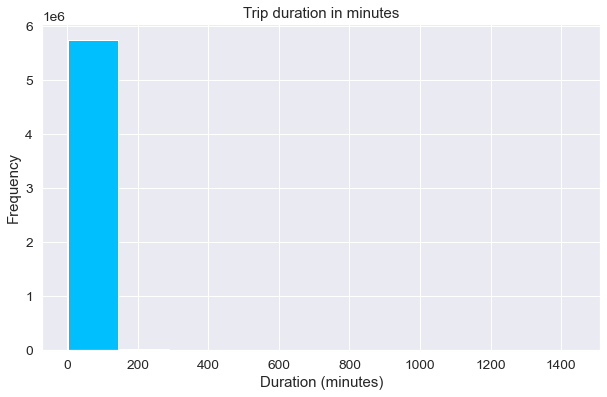

```python
# Distribution of minutes

plt.figure(figsize = [10, 6])
plt.hist(data=df_clean, x='duration_minute', color = 'deepskyblue')
plt.title('Trip duration in minutes')
plt.xlabel('Duration (minutes)')
plt.ylabel('Frequency')
plt.show();
```

I suspect I need to stipulate bins more clearly for the histogram to show something of use. It appears that some outliers (beyond the two clear extreme ones that were removed) still exist.

```python
# Describe the dataset

df_clean.describe().apply(lambda s: s.apply(lambda x: format(x, 'g')))
```

|  | duration_sec | start_station_id | start_station_latitude | start_station_longitude | end_station_id | end_station_latitude | end_station_longitude | bike_id | start_time_month | start_time_day | start_time_hour | start_time_year | duration_minute |
| --- | --- | --- | --- | --- | --- | --- | --- | --- | --- | --- | --- | --- | --- |
| count | 5.78038e+06 | 5.21431e+06 | 5.78038e+06 | 5.78038e+06 | 5.21265e+06 | 5.78038e+06 | 5.78038e+06 | 5.78038e+06 | 5.78038e+06 | 5.78038e+06 | 5.78038e+06 | 5.78038e+06 | 5.78038e+06 |
| mean | 849.224 | 134.157 | 37.7636 | -122.352 | 131.009 | 37.7632 | -122.35 | 65717.6 | 6.16998 | 15.7547 | 13.5351 | 2018.65 | 14.1537 |
| std | 2177.8 | 115.859 | 0.143441 | 0.341383 | 115.062 | 0.201344 | 0.57112 | 184814 | 3.52712 | 8.75603 | 4.76221 | 0.845414 | 36.2966 |
| min | 60 | 3 | 0 | -122.514 | 3 | 0 | -122.576 | 4 | 1 | 1 | 0 | 2017 | 1 |
| 25% | 360 | 39 | 37.7698 | -122.414 | 33 | 37.77 | -122.412 | 1634 | 3 | 8 | 9 | 2018 | 6 |
| 50% | 571 | 95 | 37.7806 | -122.399 | 92 | 37.7809 | -122.398 | 3153 | 6 | 16 | 14 | 2019 | 9.51667 |
| 75% | 893 | 209 | 37.7954 | -122.388 | 200 | 37.7954 | -122.388 | 9572 | 9 | 23 | 17 | 2019 | 14.8833 |
| max | 86369 | 521 | 45.51 | 0 | 521 | 45.51 | 0 | 999960 | 12 | 31 | 23 | 2020 | 1439.48 |

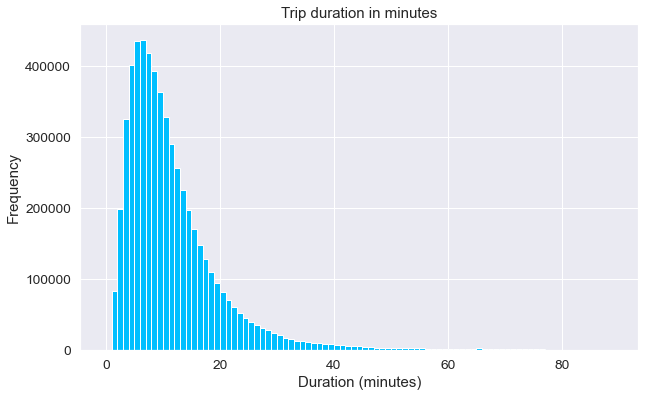

```python
# Distribution of duration (minutes), with bins and filtering

plt.figure(figsize = [10, 6])
bin_edges = np.arange(0, 90, 1)
plt.hist(data=df_clean, x='duration_minute', bins=bin_edges, color = 'deepskyblue')
plt.title('Trip duration in minutes')
plt.xlabel('Duration (minutes)')
plt.ylabel('Frequency')
plt.show();
```

From the histogram, it is evident that most trips hover around the 10 minute mark. It appears that the majority of the trips are quite short in nature, which adds more weight to my hypothesis that the bike ride share system is used for commuting.

### Discuss the distribution(s) of your variable(s) of interest. Were there any unusual points? Did you need to perform any transformations?

I needed to add bins and zoom into the area of interest for the distribution to produce useful results due to the presence of a small amount of outliers.

The distribution of duration in minutes suggests that most bike share rides are quite short in nature (approximately 10 minutes).

### Of the features you investigated, were there any unusual distributions? Did you perform any operations on the data to tidy, adjust, or change the form of the data? If so, why did you do this?

As aforementioned, I had to filter in and add bins for the histogram to show the distribution across the bulk of the data due to the presence of some outliers.

## Bivariate Exploration

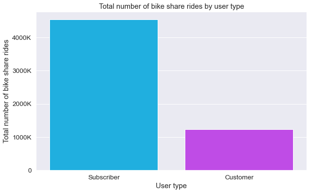

```python
# Plot the breakdown of user type

plt.figure(figsize = [10, 6])
plt.ticklabel_format(style='plain', axis='y')
colors = ['#00bfff', '#cc33ff']
sns.set_palette(colors)
ax = sns.countplot(data=df_clean, x='user_type', order=df_clean.user_type.value_counts().index)
ax.set(xlabel='User type', ylabel='Total number of bike share rides')
plt.title('Total number of bike share rides by user type')
ax.yaxis.set_major_formatter(tick.FuncFormatter(transform_axis_format))
plt.show();
```

It is clear that the majority of bike share rides are from subscribers rather than one-off customers.

```python
# Find % breakdown

customer = df_clean.query('user_type == "Customer"')['bike_id'].count()
subscriber = df_clean.query('user_type == "Subscriber"')['bike_id'].count()

print(customer / df_clean['bike_id'].count())
print(subscriber / df_clean['bike_id'].count())
```

```
0.2134508341572404
0.7865491658427596
```

Yes, 78.7% of the total user base is made up of subscribers.

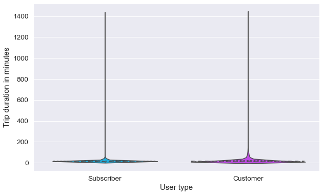

```python
# Look at the distribution between subscribers and customers

plt.figure(figsize = [10, 6])
colors = ["#00bfff", "#cc33ff"]
sns.set_palette(colors)
sns.violinplot(data=df_clean, x='user_type', y='duration_minute', inner='quartile')
plt.xlabel('User type')
plt.ylabel('Trip duration in minutes')
plt.show();
```

Again, due to the presence of some extreme outliers, I will need to filter the dataset accordingly to get a meaningful output. Given most of the rides fall under 60 minutes and below, I will use this as the benchmark between outlier and typical use.

```python
# Define outliers as rides > 60 minutes

outliers = df_clean[df_clean['duration_minute'] > 60]
outliers
```

|  | duration_sec | start_time | end_time | start_station_id | start_station_latitude | start_station_longitude | end_station_id | end_station_latitude | end_station_longitude | bike_id | user_type | start_time_month_name | start_time_month | start_time_weekday | start_time_day | start_time_hour | start_time_year_month | start_time_year | duration_minute |
| --- | --- | --- | --- | --- | --- | --- | --- | --- | --- | --- | --- | --- | --- | --- | --- | --- | --- | --- | --- |
| 2 | 18587 | 2018-02-28 18:20:55.190 | 2018-02-28 23:30:42.925 | 93.0 | 37.770407 | -122.391198 | 15.0 | 37.795392 | -122.394203 | 3498 | Customer | February | 2 | Wed | 28 | 18 | 18-02 | 2018 | 309.783333 |
| 3 | 18558 | 2018-02-28 18:20:53.621 | 2018-02-28 23:30:12.450 | 93.0 | 37.770407 | -122.391198 | 15.0 | 37.795392 | -122.394203 | 3129 | Customer | February | 2 | Wed | 28 | 18 | 18-02 | 2018 | 309.300000 |
| 183 | 4196 | 2018-02-28 19:37:42.381 | 2018-02-28 20:47:38.567 | 181.0 | 37.811377 | -122.265192 | 162.0 | 37.800516 | -122.272080 | 1268 | Customer | February | 2 | Wed | 28 | 19 | 18-02 | 2018 | 69.933333 |
| 310 | 12493 | 2018-02-28 16:29:20.590 | 2018-02-28 19:57:33.963 | 21.0 | 37.789625 | -122.400811 | 5.0 | 37.783899 | -122.408445 | 3344 | Customer | February | 2 | Wed | 28 | 16 | 18-02 | 2018 | 208.216667 |
| 898 | 36573 | 2018-02-28 07:59:34.204 | 2018-02-28 18:09:08.016 | 99.0 | 37.767037 | -122.415443 | 47.0 | 37.780955 | -122.399749 | 2016 | Subscriber | February | 2 | Wed | 28 | 7 | 18-02 | 2018 | 609.550000 |
| ... | ... | ... | ... | ... | ... | ... | ... | ... | ... | ... | ... | ... | ... | ... | ... | ... | ... | ... | ... |
| 5779106 | 6086 | 2019-02-01 07:00:02.042 | 2019-02-01 08:41:28.251 | 380.0 | 37.779047 | -122.447291 | 377.0 | 37.771917 | -122.453704 | 4956 | Subscriber | February | 2 | Fri | 1 | 7 | 19-02 | 2019 | 101.433333 |
| 5779384 | 13609 | 2019-02-01 04:38:43.601 | 2019-02-01 08:25:33.493 | 106.0 | 37.763242 | -122.430675 | 79.0 | 37.773492 | -122.403673 | 4944 | Subscriber | February | 2 | Fri | 1 | 4 | 19-02 | 2019 | 226.816667 |
| 5780188 | 17953 | 2019-02-01 01:39:13.098 | 2019-02-01 06:38:26.681 | 86.0 | 37.769305 | -122.426826 | 356.0 | 37.769188 | -122.422285 | 2947 | Customer | February | 2 | Fri | 1 | 1 | 19-02 | 2019 | 299.216667 |
| 5780279 | 13251 | 2019-02-01 01:03:11.362 | 2019-02-01 04:44:03.321 | 31.0 | 37.783813 | -122.434559 | 13.0 | 37.794231 | -122.402923 | 4889 | Customer | February | 2 | Fri | 1 | 1 | 19-02 | 2019 | 220.850000 |
| 5780299 | 5713 | 2019-02-01 01:02:55.168 | 2019-02-01 02:38:09.002 | 31.0 | 37.783813 | -122.434559 | 31.0 | 37.783813 | -122.434559 | 5366 | Subscriber | February | 2 | Fri | 1 | 1 | 19-02 | 2019 | 95.216667 |

89939 rows × 19 columns

```python
# Define typical as rides <= 60 minutes

typical = df_clean[df_clean['duration_minute'] <= 60]
typical
```

|  | duration_sec | start_time | end_time | start_station_id | start_station_latitude | start_station_longitude | end_station_id | end_station_latitude | end_station_longitude | bike_id | user_type | start_time_month_name | start_time_month | start_time_weekday | start_time_day | start_time_hour | start_time_year_month | start_time_year | duration_minute |
| --- | --- | --- | --- | --- | --- | --- | --- | --- | --- | --- | --- | --- | --- | --- | --- | --- | --- | --- | --- |
| 0 | 598 | 2018-02-28 23:59:47.097 | 2018-03-01 00:09:45.187 | 284.0 | 37.784872 | -122.400876 | 114.0 | 37.764478 | -122.402570 | 1035 | Subscriber | February | 2 | Wed | 28 | 23 | 18-02 | 2018 | 9.966667 |
| 1 | 943 | 2018-02-28 23:21:16.495 | 2018-02-28 23:36:59.974 | 6.0 | 37.804770 | -122.403234 | 324.0 | 37.788300 | -122.408531 | 1673 | Customer | February | 2 | Wed | 28 | 23 | 18-02 | 2018 | 15.716667 |
| 4 | 885 | 2018-02-28 23:15:12.858 | 2018-02-28 23:29:58.608 | 308.0 | 37.336802 | -121.894090 | 297.0 | 37.322980 | -121.887931 | 1839 | Subscriber | February | 2 | Wed | 28 | 23 | 18-02 | 2018 | 14.750000 |
| 5 | 921 | 2018-02-28 23:14:19.170 | 2018-02-28 23:29:40.437 | 312.0 | 37.329732 | -121.901782 | 288.0 | 37.350964 | -121.902016 | 2656 | Customer | February | 2 | Wed | 28 | 23 | 18-02 | 2018 | 15.350000 |
| 6 | 277 | 2018-02-28 23:21:49.274 | 2018-02-28 23:26:27.222 | 316.0 | 37.330165 | -121.885831 | 310.0 | 37.335885 | -121.885660 | 1616 | Subscriber | February | 2 | Wed | 28 | 23 | 18-02 | 2018 | 4.616667 |
| ... | ... | ... | ... | ... | ... | ... | ... | ... | ... | ... | ... | ... | ... | ... | ... | ... | ... | ... | ... |
| 5780380 | 480 | 2019-02-01 00:04:49.724 | 2019-02-01 00:12:50.034 | 27.0 | 37.788059 | -122.391865 | 324.0 | 37.788300 | -122.408531 | 4832 | Subscriber | February | 2 | Fri | 1 | 0 | 19-02 | 2019 | 8.000000 |
| 5780381 | 313 | 2019-02-01 00:05:34.744 | 2019-02-01 00:10:48.502 | 21.0 | 37.789625 | -122.400811 | 66.0 | 37.778742 | -122.392741 | 4960 | Subscriber | February | 2 | Fri | 1 | 0 | 19-02 | 2019 | 5.216667 |
| 5780382 | 141 | 2019-02-01 00:06:05.549 | 2019-02-01 00:08:27.220 | 278.0 | 37.331932 | -121.904888 | 277.0 | 37.333658 | -121.908586 | 3824 | Subscriber | February | 2 | Fri | 1 | 0 | 19-02 | 2019 | 2.350000 |
| 5780383 | 139 | 2019-02-01 00:05:34.360 | 2019-02-01 00:07:54.287 | 220.0 | 37.811351 | -122.273422 | 216.0 | 37.817827 | -122.275698 | 5095 | Subscriber | February | 2 | Fri | 1 | 0 | 19-02 | 2019 | 2.316667 |
| 5780384 | 271 | 2019-02-01 00:00:20.636 | 2019-02-01 00:04:52.058 | 24.0 | 37.789677 | -122.390428 | 37.0 | 37.785000 | -122.395936 | 1057 | Subscriber | February | 2 | Fri | 1 | 0 | 19-02 | 2019 | 4.516667 |

5690446 rows × 19 columns

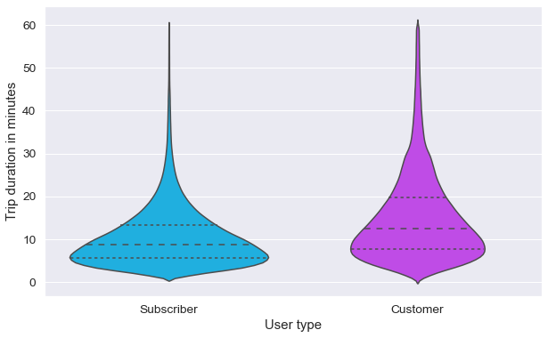

```python
# Look at the distribution between subscribers and customers

plt.figure(figsize = [10, 6])
colors = ['#00bfff', '#cc33ff']
sns.set_palette(colors)
sns.violinplot(data=typical, x='user_type', y='duration_minute', inner='quartile')
plt.xlabel('User type')
plt.ylabel('Trip duration in minutes')
plt.show();
```

The duration distribution is much narrower for subscription users who typically have quite a short trip on the whole. In comparison, the distribution for customers is slightly wider and indicates that one-off customers may have a longer ride than a typical commute style ride as seems to be the case for subscribers.

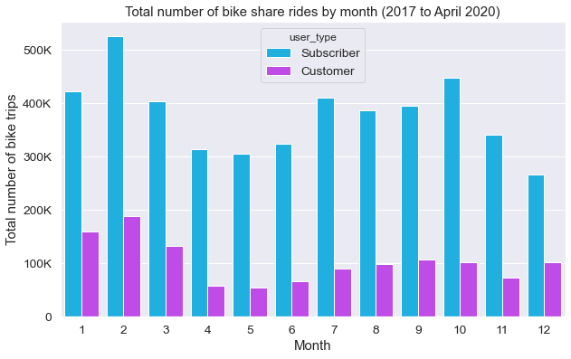

```python
# Monthly bike share rides

plt.figure(figsize = [10, 6])
weekday = ['Mon', 'Tue', 'Wed', 'Thu', 'Fri', 'Sat', 'Sun']
colors = ['#00bfff', '#cc33ff']
ax = sns.countplot(data=df_clean, x='start_time_month', hue='user_type')
ax.set(xlabel='Month', ylabel='Total number of bike trips')
plt.title('Total number of bike share rides by month (2017 to April 2020)')
ax.yaxis.set_major_formatter(tick.FuncFormatter(transform_axis_format))
plt.show();
```

Bike share rides on a monthly basis seem to follow a similar trend for both subscribers and customers alike.

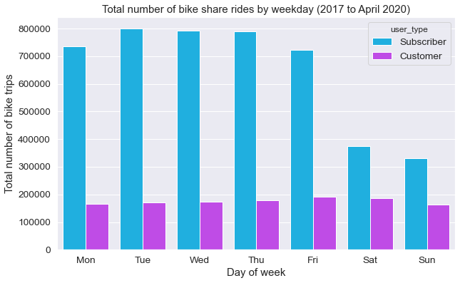

```python
# Weekday bike share rides

plt.figure(figsize = [10, 6])
weekday = ['Mon', 'Tue', 'Wed', 'Thu', 'Fri', 'Sat', 'Sun']
colors = ["#00bfff", "#cc33ff"]
sns.set_palette(colors)
sns.countplot(data=df_clean, x='start_time_weekday', order=weekday, hue='user_type')
plt.xlabel('Day of week')
plt.ylabel('Total number of bike trips')
plt.title('Total number of bike share rides by weekday (2017 to April 2020)')
ax.yaxis.set_major_formatter(tick.FuncFormatter(transform_axis_format))
plt.show();
```

Whilst the weekend effect is present for subscribers, it does not appear that there is a weekend effect for customers. Usage for customers is constant across each day of the week.

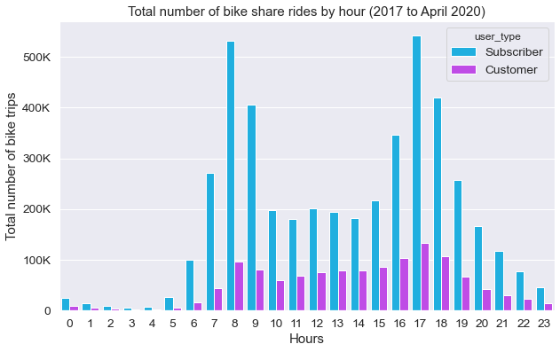

```python
# Hourly bike share rides

plt.figure(figsize = [10, 6])
colors = ["#00bfff", "#cc33ff"]
sns.set_palette(colors)
ax = sns.countplot(data=df_clean, x='start_time_hour', hue='user_type')
ax.set(xlabel='Hours', ylabel='Total number of bike trips')
plt.title('Total number of bike share rides by hour (2017 to April 2020)')
ax.yaxis.set_major_formatter(tick.FuncFormatter(transform_axis_format))
plt.show();
```

From an hourly perspective, the peaks for subscribers are centred around peak commute times (8:00 am – 9:00 am and 5:00 pm – 6:00 pm); however, this is much less pronounced for customers. There is quite consistent usage for customers from 8:00 am through to 6:00 pm.

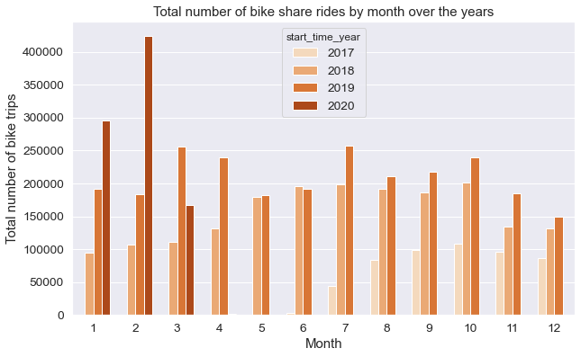

```python
# Monthly bike share rides, by year

plt.figure(figsize = [10, 6])
sns.countplot(data=df_clean, x='start_time_month', palette='Oranges', hue='start_time_year')
plt.title('Total number of bike share rides by month over the years')
plt.ylabel('Total number of bike trips')
plt.xlabel('Month')
plt.show();
```

This is an interesting one to look at.

I will make a couple of key points.

- There appears to be consistent growth across the years in total monthly bike trips.
- There is very rapid growth observed at the start of 2020 in the months of January and February.
- Then, in March, there is a sudden reversal with a significant drop. In my view, this possibly reflects the impact of COVID-19. It would be interesting to extend this study further and look to wrangle in the datasets for months May onwards to further study this effect.

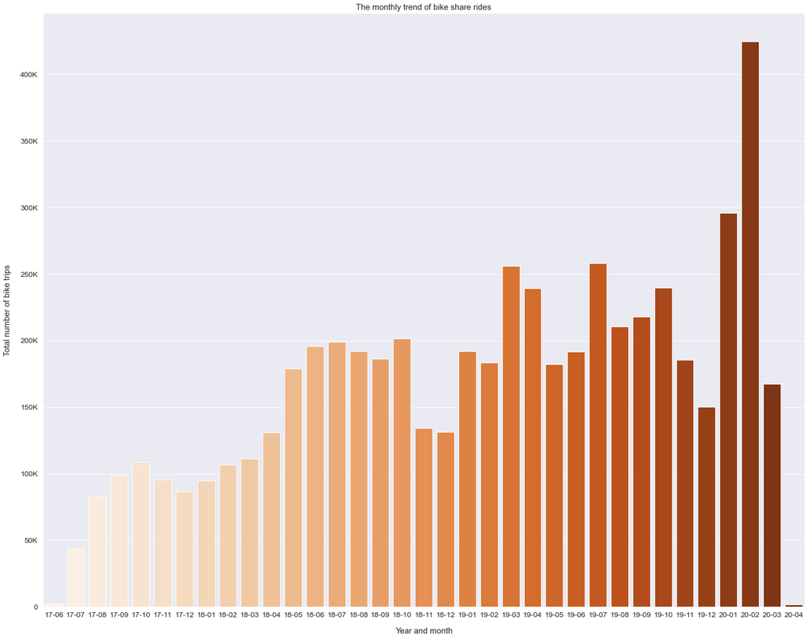

```python
# Monthly trend of total bike share rides

plt.figure(figsize=(25,20))
sns.countplot(x='start_time_year_month', palette="Oranges", data=df_clean.sort_values(by='start_time_year_month'))
plt.title('The monthly trend of bike share rides')
plt.xlabel('Year and month', labelpad=16)
plt.ylabel('Total number of bike trips', labelpad=16)
ax = plt.gca()
ax.yaxis.set_major_formatter(tick.FuncFormatter(transform_axis_format))
```

This further shows the strong monthly growth in bike share rides over the years, and a particular up shot at the start of 2020, only for the bubble to be so prematurely burst at the start of COVID-19 restrictions in March 2020.

### Talk about some of the relationships you observed in this part of the investigation. How did the feature(s) of interest vary with other features in the dataset?

I found that the duration distribution between customers and subscribers was interesting and it added more weight to my hypothesis that subscribers use the ride share service for commuting (thus, a narrower duration distribution); wheras, customers have a wider duration distribution indicating the prevalance of longer rides.

### Did you observe any interesting relationships between the other features (not the main feature(s) of interest)?

Some of the most interesting relationships I found was the monthly number of bike share rides when compared against month and year. This showed the strong growth in the service over time, a particularly rapid episode of growth in early 2020, and a significant drop in usage from March 2020.

## Multivariate Exploration

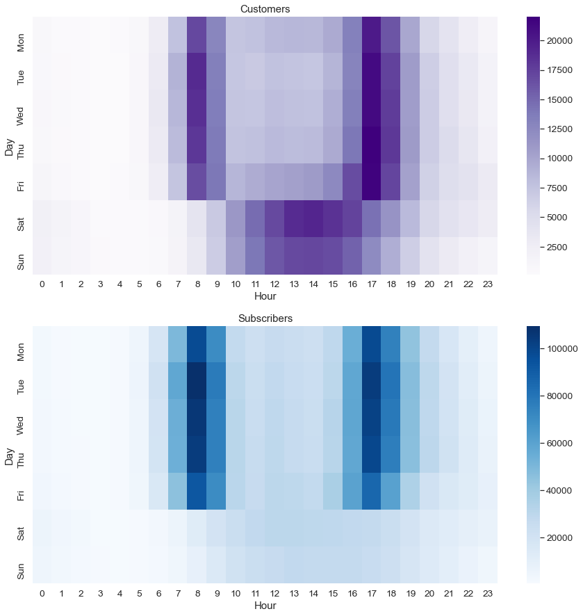

```python
# Set up for heatmap

plt.suptitle('Hourly usage throughout the week by user type')

df_clean['start_time_weekday'] = pd.Categorical(df_clean['start_time_weekday'],
                                                categories=['Mon','Tue','Wed','Thu','Fri','Sat', 'Sun'],
                                                ordered=True)

plt.figure(figsize=(15,15))

# Customer heatmap

plt.subplot(2, 1, 1)
customers = df_clean.query('user_type == "Customer"')
customer_count = customers.groupby(['start_time_weekday', 'start_time_hour']).size()
customer_count = customer_count.reset_index(name='count')
customer_count = customer_count.pivot(index='start_time_weekday', columns='start_time_hour', values='count')
midpoint = (customer_count.values.max() - customer_count.values.min()) / 2
sns.heatmap(customer_count, cmap='Purples', center=midpoint)
plt.title('Customers', loc='center')
plt.xlabel('Hour')
plt.ylabel('Day')

# Subscriber heatmap

plt.subplot(2, 1, 2)
subscribers = df_clean.query('user_type == "Subscriber"')
subsciber_count = subscribers.groupby(['start_time_weekday', 'start_time_hour']).size()
subsciber_count = subsciber_count.reset_index(name='count')
subsciber_count = subsciber_count.pivot(index='start_time_weekday', columns='start_time_hour', values='count')
midpoint = (subsciber_count.values.max() - subsciber_count.values.min()) / 2
sns.heatmap(subsciber_count, cmap='Blues', center=midpoint)
plt.title('Subscribers', loc='center')
plt.xlabel('Hour')
plt.ylabel('Day')

plt.show();
```

### Talk about some of the relationships you observed in this part of the investigation. Were there features that strengthened each other in terms of looking at your feature(s) of interest?

This is a really interesting view.

From a customer perspective, we can see that most bike rides occur between 8:00 am – 9:00 am and 5:00 pm – 6:00 pm; however, there is not as much of a drop off in off-peak hours as there is with subscribers. We can also see that there are quite a number of bike rides on weekends with the times being clustered around 10:00 am – 6:00 am.

From a subscriber perspective, we can see that most bike rides occur from 8:00 am – 9:00 am and 5:00 pm – 6:00 pm, with very little other rides in off-peak time during the week. There are very little bike rides on weekends among subscribers.

### Were there any interesting or surprising interactions between features?

Whilst I was already aware of these interactions in isolation, this visualisation allowed me to view these aspects together in one view which brought it to life in an interesting manner.